# ra_rating_analysis_longitudinal

Bernice Cheung

1/17/2022

load data

```r
ra_rating_raw <- read_bulk(directory = here("RA_rating", "inputs"), fun = read_excel, sheet = 2, col_names = T, n_max = 180)
```

```
## Reading longitudinalRating_GF.xlsx
```

```
## Reading longitudinalRating_KA.xlsx
```

```
## Reading longitudinalRating_KP.xlsx
```

```
## Reading longitudinalRating_LN.xlsx
```

```
## Reading longitudinalRating_MDK.xlsx
```

```
## Reading longitudinalRating_MP.xlsx
```

```
## Reading longitudinalRating_TS.xlsx
```

```
## Reading longitudinalRating_ZH.xlsx
```

recode data

```r
# group variables based on weather it's unipolar / bipolar
uni_col <- c("measurability", "meaningfulness", "importance", "instrumentality", "visibility", "external_importance","affordance", "difficulty")
bi_col <- c("social_desirability", "external_motivation", "introjected_motivation", "identified_motivation", "intrinsic_motivation", "ought_motivation", "ideal_motivation", "basic_needs", "commonality", "control", "clarity")

ra_rating_clean <- ra_rating_raw %>%
  mutate_at(vars(uni_col), funs(recode(.,"1: Not at all" = 1, "2" = 2, "3" = 3, "4:Neutral" = 4, "5" = 5, "6" = 6, "7: Very much" = 7, "99: I can't tell" = 99, "1.0" = 1, "2.0" = 2, "3.0" = 3, "4.0" = 4, "5.0" = 5, "6.0" = 6, "7.0" = 7))) %>%
  mutate_at(vars(bi_col), funs(recode(.,"1: Strongly disagree" = 1, "2" = 2, "3" = 3, "4: Neutral" = 4, "5" = 5, "6" = 6, "7: Strongly agree" = 7, "99: I can't tell" = 99, "1: strongly disagree" = 1,"7: strongly agree" = 7, "4:Neutral" = 4, "1.0" = 1, "2.0" = 2, "3.0" = 3, "4.0" = 4, "5.0" = 5, "6.0" = 6, "7.0" = 7))) %>%
  mutate_at(vars(specificity), funs(recode(.,"1: Very general" = 1, "2" = 2, "3" = 3, "4: moderate" = 4, "5" = 5, "6" = 6, "7: very special" = 7, "99: I can't tell" = 99, "1.0" = 1, "2.0" = 2, "3.0" = 3, "4.0" = 4, "5.0" = 5, "6.0" = 6, "7.0" = 7))) %>%
  mutate_at(vars(approach_avoidance), funs(recode(.,"1: An approach goal" = 1, "2" = 2, "3" = 3, "4: neither an approach nor an avoidance goal" = 4, "5" = 5, "6" = 6, "7: An avoidance goal" = 7, "99: I can't tell" = 99, "1.0" = 1, "2.0" = 2, "3.0" = 3, "4.0" = 4, "5.0" = 5, "6.0" = 6, "7.0" = 7))) %>%
  mutate_at(vars(attainment_maintenance), funs(recode(.,"1: An attainment goal" = 1, "2" = 2, "3" = 3, "4: neither an attainment nor a maintenance goal" = 4, "5" = 5, "6" = 6, "7: An maintenance goal" = 7, "99: I can't tell" = 99, "1.0" = 1, "2.0" = 2, "3.0" = 3, "4.0" = 4, "5.0" = 5, "6.0" = 6, "7.0" = 7))) %>%
  mutate_at(vars(attainability), funs(recode(.,"1: 0%" = 1, "2: 10%" = 2, "3: 20%" = 3, "4: 30%" = 4, "5: 40%" = 5, "6: 50%" = 6, "6:50%" = 6,"7: 60%" = 7, "8: 70%" = 8,"9: 80%" = 9,"10: 90%" = 10,"11: 100%" = 11,"99: I can't tell" = 99, "1.0" = 1, "2.0" = 2, "3.0" = 3, "4.0" = 4, "5.0" = 5, "6.0" = 6, "7.0" = 7))) %>%
  mutate_at(vars(c(attractiveness_achievement, attractiveness_progress)), funs(recode(.,"1: Not at all" = 1, "2: A little good" = 2, "3: Somewhat good" = 3, "4:Good" = 4, "5: Very good" = 5, "6: Great" = 6, "7: One of the best feelings" = 7,"99: I can't tell" = 99, "1.0" = 1, "2.0" = 2, "3.0" = 3, "4.0" = 4, "5.0" = 5, "6.0" = 6, "7.0" = 7))) %>%
  mutate_at(vars(construal_level), funs(recode(.,"1: low level" = 1, "2" = 2, "3" = 3, "4: mid level" = 4, "5" = 5, "6" = 6, "7: High Level" = 7, "99: I can't tell" = 99, "1.0" = 1, "2.0" = 2, "3.0" = 3, "4.0" = 4, "5.0" = 5, "6.0" = 6, "7.0" = 7))) %>%
  mutate_if(is.numeric, list(~na_if(., 99))) %>%
  rowwise() %>%
  mutate(ra = str_sub(File, start = (nchar("longitudinalRating_") + 1), end = -6L)) %>%
  select(-File)
```

```
## Note: Using an external vector in selections is ambiguous.
## ℹ Use `all_of(uni_col)` instead of `uni_col` to silence this message.
## ℹ See <https://tidyselect.r-lib.org/reference/faq-external-vector.html>.
```

```
## Note: Using an external vector in selections is ambiguous.
## ℹ Use `all_of(bi_col)` instead of `bi_col` to silence this message.
## ℹ See <https://tidyselect.r-lib.org/reference/faq-external-vector.html>.
```

```r
# replace the difficulty rating from ZH for now
ra_rating_clean[ra_rating_clean$ra == "ZH", "difficulty"] <- NA
```

check recoding

```r
# count the number of NAs per column

ra_rating_clean %>%
  summarise_all(funs(sum(is.na(.))))
```

```
## # A tibble: 1,440 x 34
##    Goals content content.other ought_motivation frequency identified_moti…
##    <int>   <int>         <int>            <int>     <int>            <int>
##  1     0       0             1                0         0                0
##  2     0       0             1                0         0                0
##  3     0       0             1                0         0                0
##  4     0       0             1                0         0                0
##  5     0       0             1                0         0                0
##  6     0       0             1                0         0                0
##  7     0       0             1                0         0                0
##  8     0       0             1                0         0                0
##  9     0       0             1                0         0                0
## 10     0       0             1                0         0                0
## # … with 1,430 more rows, and 28 more variables: intrinsic_motivation <int>,
## #   connectedness <int>, basic_needs <int>, attractiveness_achievement <int>,
## #   attractiveness_progress <int>, specificity <int>, approach_avoidance <int>,
## #   visibility <int>, introjected_motivation <int>,
## #   attainment_maintenance <int>, instrumentality <int>,
## #   social_desirability <int>, importance <int>, clarity <int>,
## #   ideal_motivation <int>, external_motivation <int>, affordance <int>,
## #   external_importance <int>, construal_level <int>, meaningfulness <int>,
## #   commonality <int>, temporal_duration <int>, control <int>,
## #   end_state_specificity <int>, difficulty <int>, measurability <int>,
## #   attainability <int>, ra <int>
```

# ICCs on variable ratings:

Loop through each dimension and calculate twoway agreement ICC

```r
# check duplicated goals
ra_rating_clean %>% get_dupes(Goals) %>% tally() %>%
   filter(n > 1)
```

```
## # A tibble: 0 x 1
## # … with 1 variable: n <int>
```

```r
# Extract dimension names (exclude connectivity)
varNames <- names(ra_rating_clean)[c(4, 6:7,9:12, 14,15,17: 27,29, 31: 33)]

# create a df for ICC
iccDf <- data.frame(dimension = varNames,
                    icc = NA,
                    icc_lower = NA,
                    icc_upper = NA)
ra_ratingDf_l <- data.frame(Goals = as.character(),
                      variable = as.character(),
                      RA_1 = as.numeric(),
                      RA_2 = as.numeric())


# loop through each dimension and extract twoway agreement ICC
rowIdx = 1
for (var in varNames){
  # extract data
  varDf <- ra_rating_clean[,c("Goals", var, "ra")]
  # transform it to the wide format (exclude duplicated goals)
  varDf_w <-  varDf %>%
  spread(ra, var) %>% select(-Goals)
  # transform it to the long format
  varDf_l <- varDf %>%
    group_by(Goals) %>%
    mutate(goalOrder = 1:n(),
          ra_id = paste("RA", goalOrder, sep = "_"),
          variable = var) %>%
    select(-ra, -goalOrder) %>%
    spread(ra_id, var) %>%
    select(-c(RA_3:RA_4))
  # merge the long format dataset
  ra_ratingDf_l <- rbind(ra_ratingDf_l, varDf_l)
  # calculate ICC
  icc_result <- iccNA(varDf_w, rho0 = 0, conf = 0.95, Cs = 10000, detail = FALSE)
  # extract and score the result to iccDf
  iccDf[rowIdx,2] <- round(icc_result$ICCs[2,1], 3)
  iccDf[rowIdx,3] <- round(icc_result$ICCs[2,3], 4)
  iccDf[rowIdx,4] <- round(icc_result$ICCs[2,4], 3)
  rowIdx = rowIdx + 1
}
```

```r
iccDf %>%
  arrange(desc(icc)) %>%
  kable(format = "html", escape = F, caption = "<center>RA rating ICC</center>") %>%
  kable_styling(bootstrap_options = c("striped", "hover", "condensed"), full_width = F,position = "center",fixed_thead = T)
```

RA rating ICC

| dimension | icc | icc_lower | icc_upper |
| --- | --- | --- | --- |
| specificity | 0.669 | 0.6169 | 0.714 |
| commonality | 0.570 | 0.5006 | 0.629 |
| intrinsic_motivation | 0.536 | 0.4622 | 0.599 |
| measurability | 0.520 | 0.4444 | 0.586 |
| difficulty | 0.519 | 0.4321 | 0.592 |
| external_motivation | 0.471 | 0.3856 | 0.545 |
| instrumentality | 0.463 | 0.3759 | 0.537 |
| basic_needs | 0.460 | 0.3742 | 0.534 |
| introjected_motivation | 0.450 | 0.3616 | 0.525 |
| external_importance | 0.445 | 0.3551 | 0.522 |
| social_desirability | 0.414 | 0.3210 | 0.495 |
| importance | 0.384 | 0.2840 | 0.469 |
| attractiveness_achievement | 0.379 | 0.2810 | 0.464 |
| visibility | 0.373 | 0.2710 | 0.460 |
| construal_level | 0.359 | 0.2581 | 0.447 |
| meaningfulness | 0.344 | 0.2376 | 0.435 |
| ideal_motivation | 0.300 | 0.1884 | 0.396 |
| ought_motivation | 0.283 | 0.1680 | 0.383 |
| identified_motivation | 0.210 | 0.0852 | 0.318 |
| clarity | 0.207 | 0.0814 | 0.315 |
| attainability | 0.138 | -0.0015 | 0.258 |
| attractiveness_progress | 0.108 | -0.0325 | 0.230 |
| control | 0.078 | -0.0681 | 0.203 |
| affordance | 0.072 | -0.0770 | 0.200 |

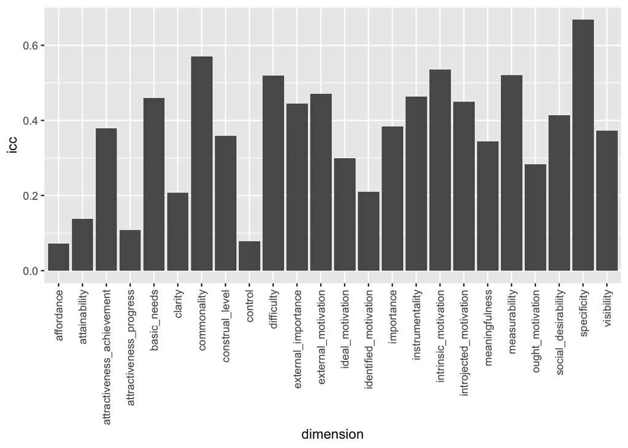

```r
# visualization:
iccDf %>%
  ggplot(aes(x=dimension, y = icc)) + geom_bar(stat="identity") +
  theme(axis.text.x = element_text(angle = 90, vjust = 0.5, hjust=1))
```

histogram of the RA rating: Compared to the actual ratings, the ra ratings are much less skewed

```
## Note: Using an external vector in selections is ambiguous.
## ℹ Use `all_of(varNames)` instead of `varNames` to silence this message.
## ℹ See <https://tidyselect.r-lib.org/reference/faq-external-vector.html>.
```

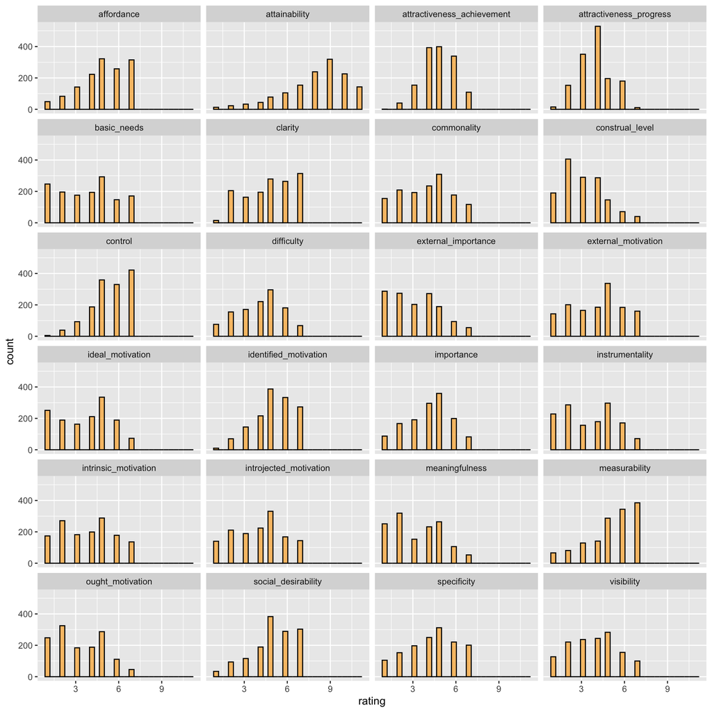

```r
ra_rating_clean %>%
  select(varNames) %>%
  gather(varNames, key = "variable", value = "rating") %>%
  ggplot(aes(x = rating)) +
    geom_histogram(fill   = "orange",
                   colour = "black",
                   alpha  = .6) +
    facet_wrap(~variable, nrow = 7)
```

# ICCs on factor scores

All factor scores are generated based on the longitudinal factor model at baseline

generate factor score dataframe  
Notes: exclude the variable connectedness (f4: value, f6: Instrumentality)and conflict (f4: Clarity, f6: External)

```r
ra_rating_fs4 <- ra_rating_clean %>%
  mutate(Value = mean(c(attractiveness_achievement , attractiveness_progress , ideal_motivation , importance , construal_level , identified_motivation ,meaningfulness ,
                  instrumentality , difficulty), na.rm = T),
         Clarity = mean(c(clarity , attainability , measurability , affordance ,specificity , control), na.rm = T),
         External = mean(c(ought_motivation , external_motivation , external_importance , introjected_motivation , visibility), na.rm = T),
         Consensus = mean(c(-intrinsic_motivation , commonality , basic_needs , social_desirability), na.rm = T)) %>%
  dplyr::select(Goals,ra,Value,Clarity,External,Consensus)


ra_rating_fs6 <- ra_rating_clean %>%
  rowwise() %>%
  mutate(Value = mean(c(attractiveness_achievement , attractiveness_progress  , importance , construal_level , identified_motivation , ideal_motivation , meaningfulness) , na.rm = T),
         External = mean(c(ought_motivation , external_motivation , introjected_motivation , external_importance , visibility), na.rm = T),
         Attainability = mean(c(attainability ,- difficulty , clarity , affordance) , na.rm = T),
         Consensus = mean(c(commonality , basic_needs , social_desirability , - intrinsic_motivation) , na.rm = T),
         Measurability = mean(c(specificity , measurability) , na.rm = T),
         Instrumentality = mean(c(instrumentality , control) , na.rm = T)) %>%
  select(Goals, ra, Value, External, Attainability, Consensus, Measurability, Instrumentality)
```

calculate icc per factor (4-factor)

```r
# Extract dimension names (exclude connectivity)
fs4_Names <- names(ra_rating_fs4)[3:6]

# create a df for ICC
iccDf_fs4 <- data.frame(dimension = fs4_Names,
                    icc = NA,
                    icc_lower = NA,
                    icc_upper = NA)

meanScore_fs4 <- ra_rating_fs4[,c("Goals", "Value", "ra")] %>%
  spread(ra, "Value") %>%
  select(Goals)

# loop through each dimension and extract twoway agreement ICC
rowIdx = 1
for (var in fs4_Names){
  # extract data
  varDf <- ra_rating_fs4[,c("Goals", var, "ra")]
  # transform it to the wide format (exclude duplicated goals)
  varDf_w <-  varDf %>%
  spread(ra, var) %>% select(-Goals)
  # calculate mean RA rating for each factor
  meanScore_fs4[paste0(var,"_raMean")] = rowMeans(varDf_w, na.rm = T)
  # calculate ICC
  icc_result <- iccNA(varDf_w, rho0 = 0, conf = 0.95, Cs = 10000, detail = FALSE)
  # extract and score the result to iccDf_fs4
  iccDf_fs4[rowIdx,2] <- round(icc_result$ICCs[2,1], 3)
  iccDf_fs4[rowIdx,3] <- round(icc_result$ICCs[2,3], 3)
  iccDf_fs4[rowIdx,4] <- round(icc_result$ICCs[2,4], 3)
  rowIdx = rowIdx + 1
}
```

generate a table

```r
iccDf_fs4 %>%
  kable(format = "html", escape = F, caption = "<center>RA 4factor score ICC</center>") %>%
  kable_styling(bootstrap_options = c("striped", "hover", "condensed"), full_width = F,position = "center",fixed_thead = T)
```

RA 4factor score ICC

| dimension | icc | icc_lower | icc_upper |
| --- | --- | --- | --- |
| Value | 0.538 | 0.465 | 0.601 |
| Clarity | 0.348 | 0.245 | 0.437 |
| External | 0.491 | 0.410 | 0.560 |
| Consensus | 0.606 | 0.544 | 0.660 |

calculate icc per factor (6-factor)

```r
# Extract dimension names (exclude connectivity)
fs6_Names <- names(ra_rating_fs6)[3:8]

# create a df for ICC
iccDf_fs6 <- data.frame(dimension = fs6_Names,
                    icc = NA,
                    icc_lower = NA,
                    icc_upper = NA)

meanScore_fs6 <- ra_rating_fs6[,c("Goals", "Value", "ra")] %>%
  spread(ra, "Value") %>%
  select(Goals)

# loop through each dimension and extract twoway agreement ICC
rowIdx = 1
for (var in fs6_Names){
  # extract data
  varDf <- ra_rating_fs6[,c("Goals", var, "ra")]
  # transform it to the wide format (exclude duplicated goals)
  varDf_w <-  varDf %>%
  spread(ra, var) %>% select(-Goals)
  # calculate mean RA rating for each factor
  meanScore_fs6[paste0(var,"_raMean")] = rowMeans(varDf_w, na.rm = T)
  # calculate ICC
  icc_result <- iccNA(varDf_w, rho0 = 0, conf = 0.95, Cs = 10000, detail = FALSE)
  # extract and score the result to iccDf_fs6
  iccDf_fs6[rowIdx,2] <- round(icc_result$ICCs[2,1], 3)
  iccDf_fs6[rowIdx,3] <- round(icc_result$ICCs[2,3], 3)
  iccDf_fs6[rowIdx,4] <- round(icc_result$ICCs[2,4], 3)
  rowIdx = rowIdx + 1
}
```

generate a table

```r
iccDf_fs6 %>%
  kable(format = "html", escape = F, caption = "<center>RA 6 factor score ICC</center>") %>%
  kable_styling(bootstrap_options = c("striped", "hover", "condensed"), full_width = F,position = "center",fixed_thead = T)
```

RA 6 factor score ICC

| dimension | icc | icc_lower | icc_upper |
| --- | --- | --- | --- |
| Value | 0.481 | 0.400 | 0.552 |
| External | 0.491 | 0.410 | 0.560 |
| Attainability | 0.135 | -0.001 | 0.253 |
| Consensus | 0.606 | 0.544 | 0.660 |
| Measurability | 0.655 | 0.600 | 0.702 |
| Instrumentality | 0.251 | 0.133 | 0.353 |

# Comparison with the actual data

## Variable ratings

long the longitudinal baseline dataset

```r
# load the longitudinal baseline dataset
base_df <- read.csv(here("Baseline", "Outputs", "goalList_rating.csv"))

# transform to long format
base_df_l <- base_df %>%
  select(-c(MTurkCode,goal_order, listNum, total_goal, goalType,approach_avoidance_R, attainment_maintenance_R,  end_state_specificity_R, failure, frequency_R, initial_time_R, other_resources, commitment, conflict,effort, implementation_intention, procrastination, regret,self_resources, connectedness, temporal_duration, urgency )) %>%
  gather(affordance: visibility, key = "variable", value = "subject_rating") %>%
  mutate(Goals = trimws(goals, which = "right")) %>% # get rid of the white space
  select(-goals)
```

merge with RA ratings

```r
merged_rating_l <- ra_ratingDf_l %>%
  left_join(base_df_l, by = c("Goals", "variable")) %>%
  rowwise() %>%
  mutate(ra_mean = sum(RA_1, RA_2, na.rm = T) / 2)
```

```r
merged_rating_l %>%
  group_by(variable) %>%
  summarise(na_sum = sum(is.na(subject_rating)))
```

```
## # A tibble: 24 x 2
##    variable                   na_sum
##    <chr>                       <int>
##  1 affordance                      0
##  2 attainability                   0
##  3 attractiveness_achievement      2
##  4 attractiveness_progress         0
##  5 basic_needs                     0
##  6 clarity                         0
##  7 commonality                     2
##  8 construal_level                11
##  9 control                         1
## 10 difficulty                      0
## # … with 14 more rows
```

check the # of goals that have complete data

```r
merged_rating_l_complete <- merged_rating_l %>%
   filter(!is.na(subject_rating) & !is.na(ra_mean))

length(unique(merged_rating_l_complete$Goals))
```

```
## [1] 727
```

```r
# merged_complete_sub_w <- merged_rating_l %>%
#   filter(!is.na(subject_rating) & !is.na(ra_mean)) %>% # subset rows with complete RA_mean & subject rating data
#   select(-c(RA_1, RA_2, ra_mean)) %>%
#   distinct() %>%
#   spread(variable, subject_rating)
```

```r
merged_complete_ra_w <- merged_rating_l %>%
  filter(!is.na(subject_rating) & !is.na(ra_mean)) %>% # subset rows with complete RA_mean & subject rating data
  select(-c(RA_1, RA_2, subject_rating)) %>%
  distinct() %>%
  spread(variable, ra_mean)
```

### T-test

comparison between subject ratings and ra ratings by variable:

```r
t_test_outcomes <- merged_rating_l %>%
  group_by(variable) %>%
  group_modify(~ broom::tidy(t.test(.x["subject_rating"], .x["ra_mean"]))) %>%
  mutate(p_value = round(p.value, 5)) %>%
  select(variable, estimate1, estimate2, statistic, p_value) %>%
  rename(subject_meanRating = estimate1, ra_meanRating = estimate2, t_value = statistic) %>%
  arrange(desc(t_value))
```

### Correlation

```r
var_compare_output <- merged_rating_l %>%
  group_by(variable) %>%
  group_modify(~ broom::tidy(cor.test(.x$subject_rating, .x$ra_mean, use = "pairwise.complete.obs"))) %>%
  select(variable, estimate, p.value) %>%
  rename(corr = estimate, corr_p = p.value) %>%
  mutate(corr_p = round(corr_p, 3)) %>%
  right_join(t_test_outcomes, by = "variable") %>%
  rename(t_test_p=p_value)
```

visualization

```r
var_compare_output %>%
  arrange(desc(corr)) %>%
  kable(format = "html", escape = F, caption = "<center>Comparison between subject ratings and mean RA ratings </center>") %>%
  kable_styling(bootstrap_options = c("striped", "hover", "condensed"), full_width = F,position = "center",fixed_thead = T)
```

Comparison between subject ratings and mean RA ratings

| variable | corr | corr_p | subject_meanRating | ra_meanRating | t_value | t_test_p |
| --- | --- | --- | --- | --- | --- | --- |
| commonality | 0.4696193 | 0.000 | 4.997249 | 3.689986 | 13.996219 | 0.00000 |
| intrinsic_motivation | 0.4217782 | 0.000 | 3.529492 | 3.706447 | -1.779352 | 0.07541 |
| basic_needs | 0.3464158 | 0.000 | 5.408779 | 3.684499 | 18.823703 | 0.00000 |
| measurability | 0.3139118 | 0.000 | 6.113855 | 4.949245 | 15.554411 | 0.00000 |
| specificity | 0.2656595 | 0.000 | 6.060440 | 4.219479 | 23.507102 | 0.00000 |
| instrumentality | 0.2653060 | 0.000 | 5.004121 | 3.335391 | 18.228969 | 0.00000 |
| ideal_motivation | 0.2577015 | 0.000 | 5.537723 | 3.526063 | 24.422464 | 0.00000 |
| external_motivation | 0.2448693 | 0.000 | 3.278846 | 3.797668 | -5.202611 | 0.00000 |
| external_importance | 0.2352448 | 0.000 | 4.566334 | 2.951303 | 16.906535 | 0.00000 |
| control | 0.2346815 | 0.000 | 6.241758 | 5.255830 | 15.642410 | 0.00000 |
| social_desirability | 0.2165214 | 0.000 | 5.841816 | 4.758573 | 14.592116 | 0.00000 |
| meaningfulness | 0.1947104 | 0.000 | 4.931319 | 3.078189 | 22.003758 | 0.00000 |
| ought_motivation | 0.1945707 | 0.000 | 2.725652 | 3.095336 | -4.114077 | 0.00004 |
| construal_level | 0.1710194 | 0.000 | 3.980501 | 2.985597 | 11.369132 | 0.00000 |
| introjected_motivation | 0.1644053 | 0.000 | 3.602195 | 3.812071 | -2.130356 | 0.03332 |
| attractiveness_achievement | 0.1638387 | 0.000 | 6.031637 | 4.627572 | 24.774048 | 0.00000 |
| visibility | 0.1350586 | 0.000 | 4.409904 | 3.538409 | 9.201681 | 0.00000 |
| importance | 0.1277399 | 0.001 | 6.123457 | 3.839506 | 33.522013 | 0.00000 |
| difficulty | 0.1264583 | 0.001 | 5.030178 | 3.237311 | 21.991633 | 0.00000 |
| identified_motivation | 0.1151277 | 0.002 | 6.200274 | 4.895748 | 20.724290 | 0.00000 |
| attractiveness_progress | 0.0432341 | 0.244 | 5.920439 | 3.757202 | 40.677689 | 0.00000 |
| clarity | 0.0186342 | 0.615 | 6.069959 | 4.624828 | 21.435878 | 0.00000 |
| attainability | -0.0088113 | 0.812 | 8.218107 | 7.383402 | 7.419553 | 0.00000 |
| affordance | -0.0191686 | 0.605 | 5.300412 | 4.613855 | 9.098631 | 0.00000 |

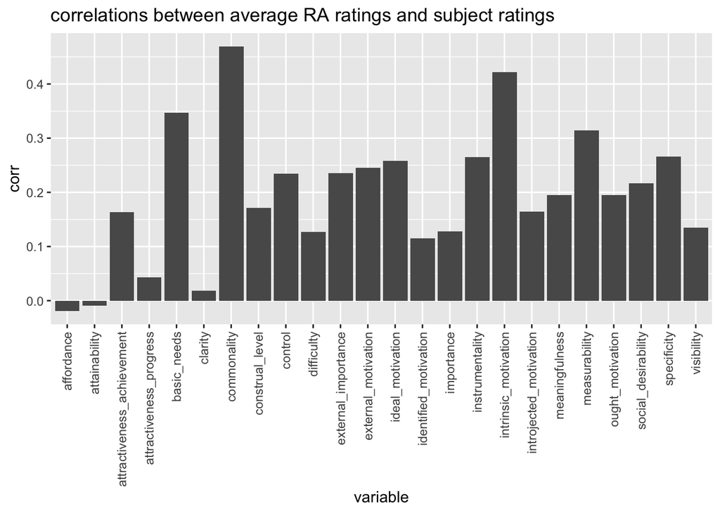

```r
# visualization:
var_compare_output %>%
  ggplot(aes(x=variable, y = corr)) + geom_bar(stat="identity") +
  theme(axis.text.x = element_text(angle = 90, vjust = 0.5, hjust=1)) +
  ggtitle("correlations between average RA ratings and subject ratings")
```

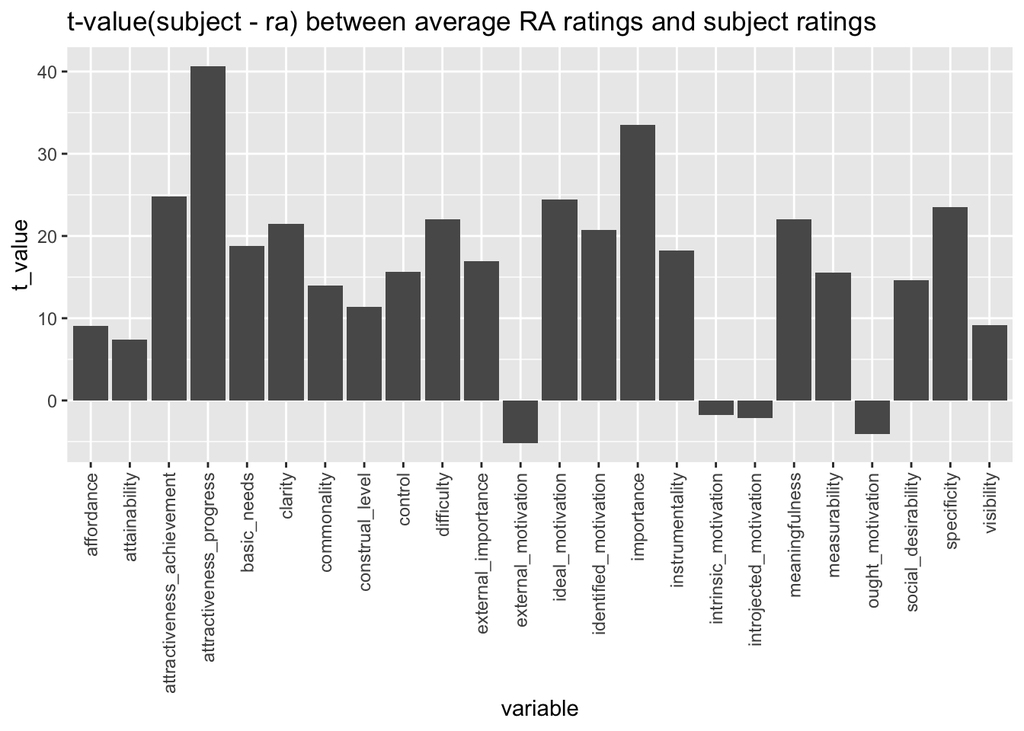

```r
# visualization:
var_compare_output %>%
  ggplot(aes(x=variable, y = t_value)) + geom_bar(stat="identity") +
  theme(axis.text.x = element_text(angle = 90, vjust = 0.5, hjust=1)) +
  ggtitle("t-value(subject - ra) between average RA ratings and subject ratings")
```

## Factor Scores

generate factor rating

```r
base_fs4_l <- base_df %>%
  rowwise() %>%
  mutate(Value = mean(c(attractiveness_achievement , attractiveness_progress , ideal_motivation , importance , construal_level , identified_motivation ,meaningfulness ,
                  instrumentality , difficulty), na.rm = T),
         Clarity = mean(c(clarity , attainability , measurability , affordance ,specificity , control), na.rm = T),
         External = mean(c(ought_motivation , external_motivation , external_importance , introjected_motivation , visibility), na.rm = T),
         Consensus = mean(c(-intrinsic_motivation , commonality , basic_needs , social_desirability), na.rm = T)) %>%
  dplyr::select(goals,Value,Clarity,External,Consensus) %>%
  gather(Value:Consensus, key = "factor", value = "subject_rating")

base_fs6_l <- base_df %>%
  rowwise() %>%
  mutate(Value = mean(c(attractiveness_achievement , attractiveness_progress  , importance , construal_level , identified_motivation , ideal_motivation , meaningfulness) , na.rm = T),
         External = mean(c(ought_motivation , external_motivation , introjected_motivation , external_importance , visibility), na.rm = T),
         Attainability = mean(c(attainability ,- difficulty , clarity , affordance) , na.rm = T),
         Consensus = mean(c(commonality , basic_needs , social_desirability , - intrinsic_motivation) , na.rm = T),
         Measurability = mean(c(specificity , measurability) , na.rm = T),
         Instrumentality = mean(c(instrumentality , control) , na.rm = T)) %>%
  select(goals, Value, External, Attainability, Consensus, Measurability, Instrumentality) %>%
  gather(Value:Instrumentality, key = "factor", value = "subject_rating")
```

merge with ra mean factor scores into a long format

```r
merged_fs4_l <- meanScore_fs4 %>%
  gather(Value_raMean:Consensus_raMean, key = "factor", value = "ra_mean") %>%
  mutate(factor = str_sub(factor, 1, -8)) %>%
  left_join(base_fs4_l, by = c("Goals" = "goals", "factor" = "factor"))

merged_fs6_l <- meanScore_fs6 %>%
  gather(Value_raMean:Instrumentality_raMean, key = "factor", value = "ra_mean") %>%
  mutate(factor = str_sub(factor, 1, -8)) %>%
  left_join(base_fs6_l, by = c("Goals" = "goals", "factor" = "factor"))
```

### T-test:

In the 4-factor model, RA ratings are lower than the subject ratings except for the external factor. In the 6-factor model, RA ratings are lower than the subject ratings on factor value measurability, instrumentality, consensus, but higher on attainability. No differences on external from both factor models

```r
t_test_outcomes_fs4 <- merged_fs4_l %>%
  group_by(factor) %>%
  group_modify(~ broom::tidy(t.test(.x["subject_rating"], .x["ra_mean"]))) %>%
  mutate(p_value = round(p.value, 5)) %>%
  select(factor, estimate1, estimate2, statistic, p_value) %>%
  rename(subject_meanRating = estimate1, ra_meanRating = estimate2, t_value = statistic) %>%
  arrange(desc(t_value))
```

```r
t_test_outcomes_fs6 <- merged_fs6_l %>%
  group_by(factor) %>%
  group_modify(~ broom::tidy(t.test(.x["subject_rating"], .x["ra_mean"]))) %>%
  mutate(p_value = round(p.value, 5)) %>%
  select(factor, estimate1, estimate2, statistic, p_value) %>%
  rename(subject_meanRating = estimate1, ra_meanRating = estimate2, t_value = statistic) %>%
  arrange(desc(t_value))
```

### Correlation

```r
var_compare_output_fs4 <- merged_fs4_l %>%
  group_by(factor) %>%
  group_modify(~ broom::tidy(cor.test(.x$subject_rating, .x$ra_mean, use = "pairwise.complete.obs"))) %>%
  select(factor, estimate, p.value) %>%
  rename(corr = estimate, corr_p = p.value) %>%
  mutate(corr_p = round(corr_p, 3)) %>%
  right_join(t_test_outcomes_fs4, by = "factor") %>%
  rename(t_test_p=p_value)

var_compare_output_fs4 %>%
  kable(format = "html", escape = F, caption = "<center>Comparison outputs on 4-factor scores </center>") %>%
  kable_styling(bootstrap_options = c("striped", "hover", "condensed"), full_width = F,position = "center",fixed_thead = T)
```

Comparison outputs on 4-factor scores

| factor | corr | corr_p | subject_meanRating | ra_meanRating | t_value | t_test_p |
| --- | --- | --- | --- | --- | --- | --- |
| Clarity | 0.1857522 | 0 | 6.329607 | 5.441766 | 19.5988558 | 0.00000 |
| Consensus | 0.5858834 | 0 | 3.209546 | 2.196762 | 16.4330254 | 0.00000 |
| External | 0.3321930 | 0 | 3.712175 | 3.727862 | -0.2317838 | 0.81674 |
| Value | 0.3170492 | 0 | 5.429896 | 3.991902 | 30.7980018 | 0.00000 |

```r
var_compare_output_fs6 <- merged_fs6_l %>%
  group_by(factor) %>%
  group_modify(~ broom::tidy(cor.test(.x$subject_rating, .x$ra_mean, use = "pairwise.complete.obs"))) %>%
  select(factor, estimate, p.value) %>%
  rename(corr = estimate, corr_p = p.value) %>%
  mutate(corr_p = round(corr_p, 3)) %>%
  right_join(t_test_outcomes_fs6, by = "factor") %>%
  rename(t_test_p=p_value)

var_compare_output_fs6 %>%
  kable(format = "html", escape = F, caption = "<center>Comparison outputs on 6-factor scores </center>") %>%
  kable_styling(bootstrap_options = c("striped", "hover", "condensed"), full_width = F,position = "center",fixed_thead = T)
```

Comparison outputs on 6-factor scores

| factor | corr | corr_p | subject_meanRating | ra_meanRating | t_value | t_test_p |
| --- | --- | --- | --- | --- | --- | --- |
| Attainability | 0.0171418 | 0.662 | 3.638208 | 3.800586 | -2.7304824 | 0.00641 |
| Consensus | 0.5858834 | 0.000 | 3.209546 | 2.196762 | 16.4330254 | 0.00000 |
| External | 0.3321930 | 0.000 | 3.712175 | 3.727862 | -0.2317838 | 0.81674 |
| Instrumentality | 0.2134475 | 0.000 | 5.625574 | 4.571142 | 19.5383676 | 0.00000 |
| Measurability | 0.3853653 | 0.000 | 6.068913 | 4.771806 | 20.1444217 | 0.00000 |
| Value | 0.2841379 | 0.000 | 5.541712 | 4.028186 | 32.0678450 | 0.00000 |

write the output

```r
var_compare_output <- var_compare_output %>%
  left_join(iccDf, by = c("variable" = "dimension"))

var_compare_output_fs4 <- var_compare_output_fs4 %>%
  left_join(iccDf_fs4, by = c("factor" = "dimension"))

var_compare_output_fs6 <- var_compare_output_fs6 %>%
  left_join(iccDf_fs6, by = c("factor" = "dimension"))

write.csv(var_compare_output, here("RA_rating", "outputs", "var_compare_output.csv"), row.names = F)
write.csv(var_compare_output_fs4, here("RA_rating", "outputs", "var_compare_output_fs4.csv"), row.names = F)
write.csv(var_compare_output_fs6, here("RA_rating", "outputs", "var_compare_output_fs6.csv"), row.names = F)
```